# PS239T Final Project Presentation

December 11, 2015

## Project Summary

This project develops code to carry out both sentiment analysis and topic modeling for a large number of articles on a single subject, in this case, *articles on Planned Parenthood from The New York Times*, from 1982 to the present.

The code, however, can be applied to any body of documents, in order to examine how the sentiment shifts over time, and to identify trends in the topics covered.

## Key Points

- The Data: was collected from LexisNexis, searcing for "Planned Parenthood" and then batch downloading the articles. I processed it using the Python code developed by Neal Caren, which worked for *most* of it.
- Analysis: consisted of *sentiment analysis* and *topic modeling*. I first conducted the analyses on a subset of the data, focusing on articles from 2009 to the present, and then included all documents from the entire date range.
- Methods: I worked in *R studio*, and used the *qdap* and *mallet* packages we learned in class.
- Challenges: the data cleaning!

## Polarity Trends Since 2009

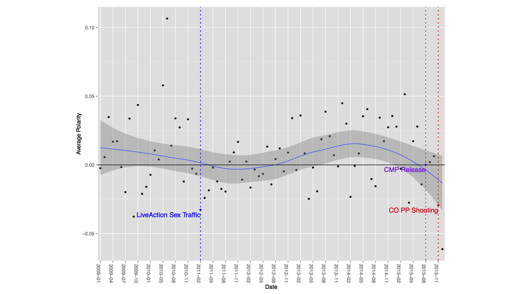

## Longer Timeline: Since 2000

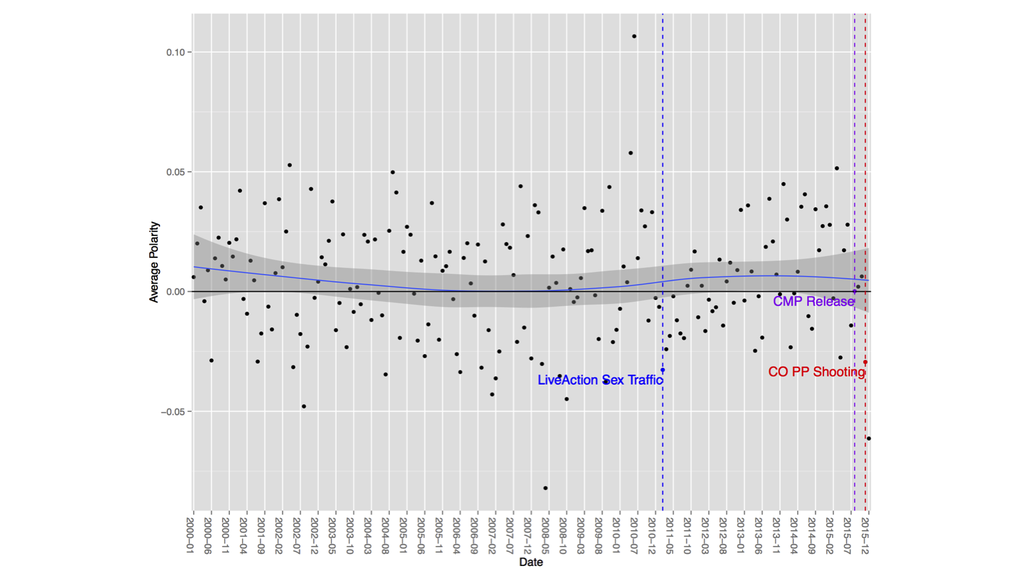

## Wordcloud: Overall Word Usage

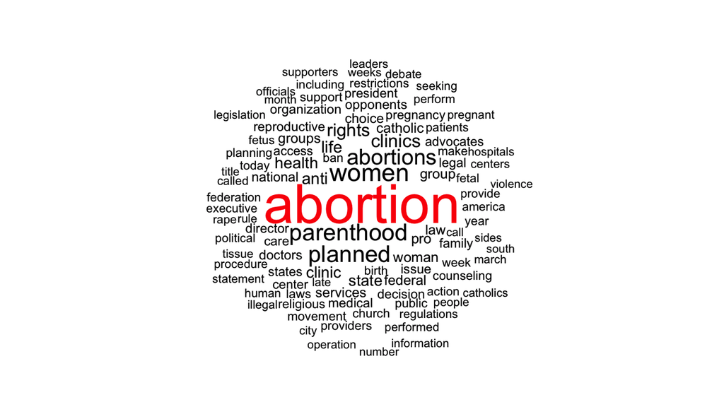

## Wordclouds: Different Topics

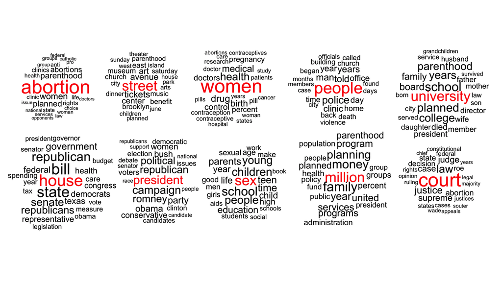

## Cluster Dendogram

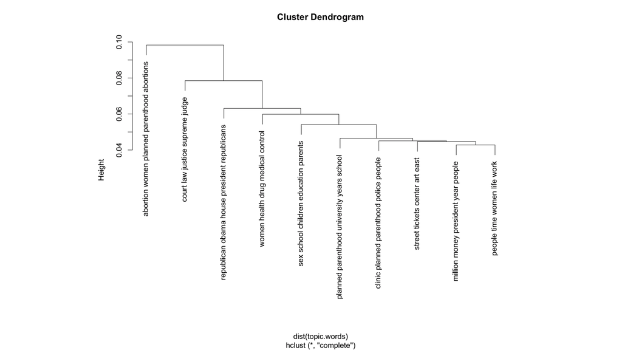